# SEACAR SAV Analysis

# Rookery Bay National Estuarine Research Reserve

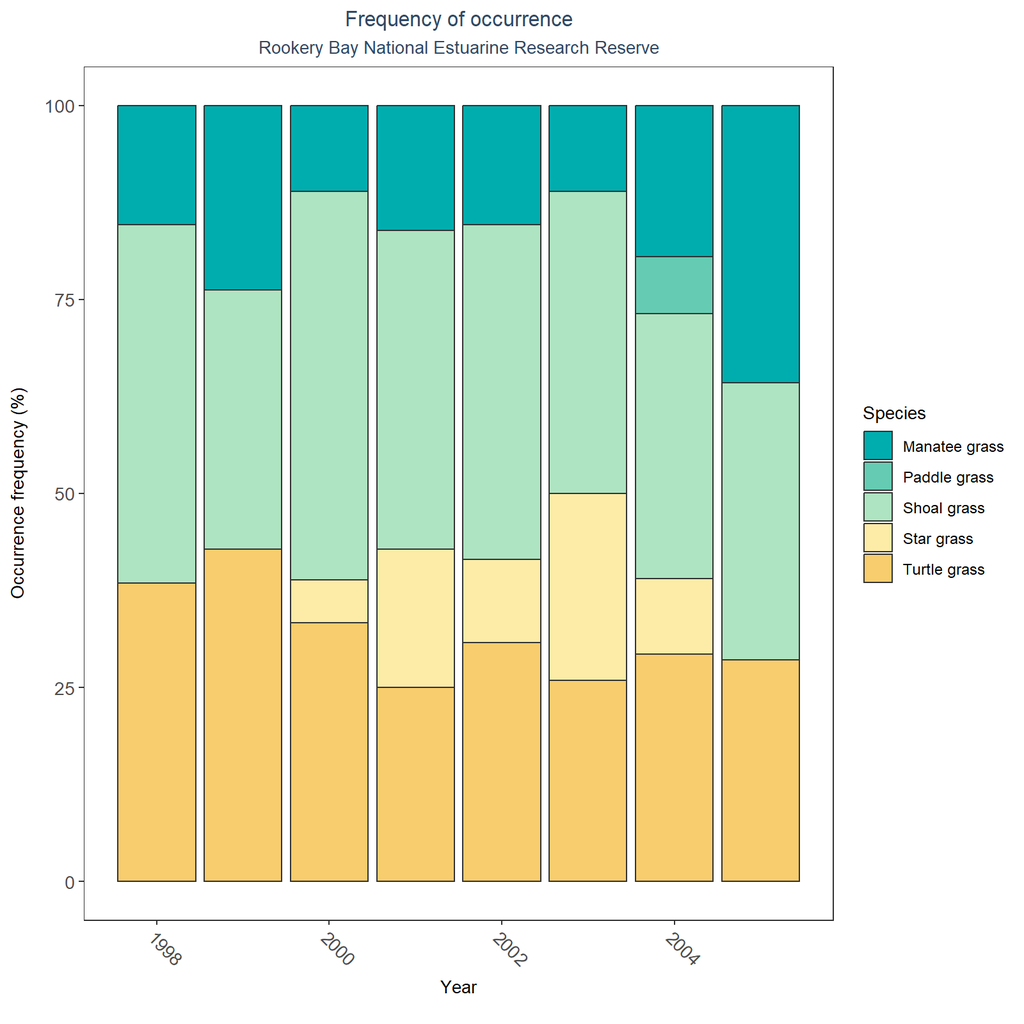

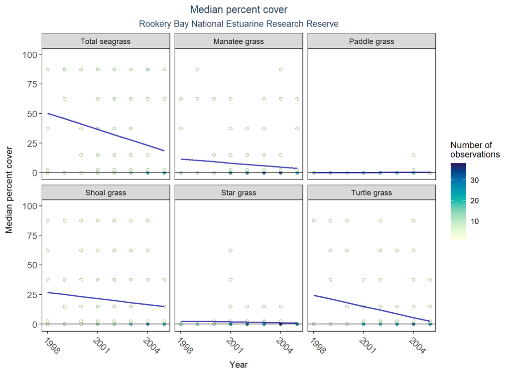

SAV LME Results for Rookery Bay National Estuarine Research Reserve

| Species | Statistical Trend | Period of Record | LME Intercept | LME Slope | p |
| --- | --- | --- | --- | --- | --- |
| Shoal grass | No detectable trend | 1998 - 2005 | 33.63 | -1.71 | 0.25 |
| Paddle grass | No detectable trend | 1998 - 2005 | -0.44 | 0.08 | 0.36 |
| Star grass | No detectable trend | 1998 - 2005 | 3.53 | -0.23 | 0.44 |
| Manatee grass | No detectable trend | 1998 - 2005 | 16.10 | -1.13 | 0.40 |
| Turtle grass | No detectable trend | 1998 - 2005 | 36.99 | -3.14 | 0.07 |
| Total seagrass | Decreasing trend | 1998 - 2005 | 68.37 | -4.52 | 0.02 |

An annual decrease in percent cover was observed for total seagrass (-4.52%). Manatee grass, paddle grass, shoal grass, star grass, and turtle grass showed no detectable change in percent cover.

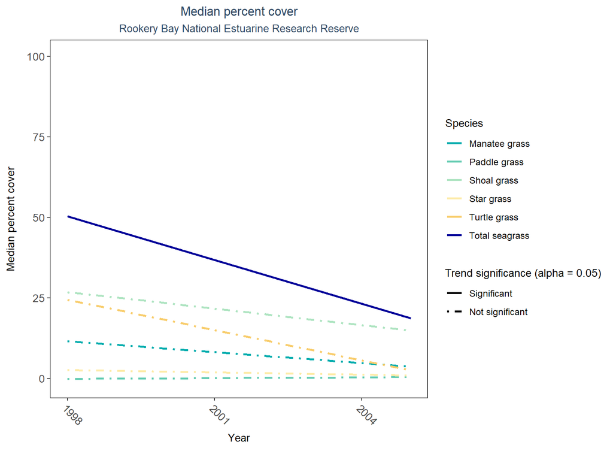

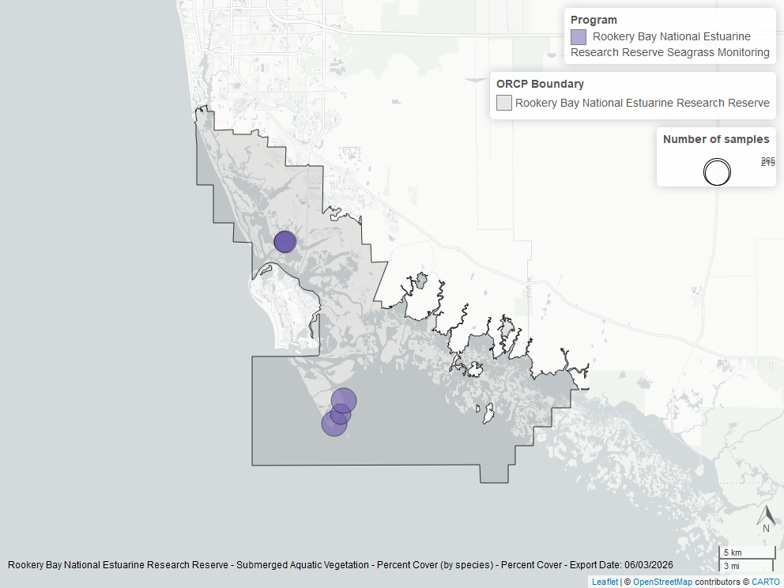

Map showing SAV sampling sites within the boundaries of *Rookery Bay National Estuarine Research Reserve*. The point size reflects the number of samples at a given sampling site.

# St. Andrews Aquatic Preserve

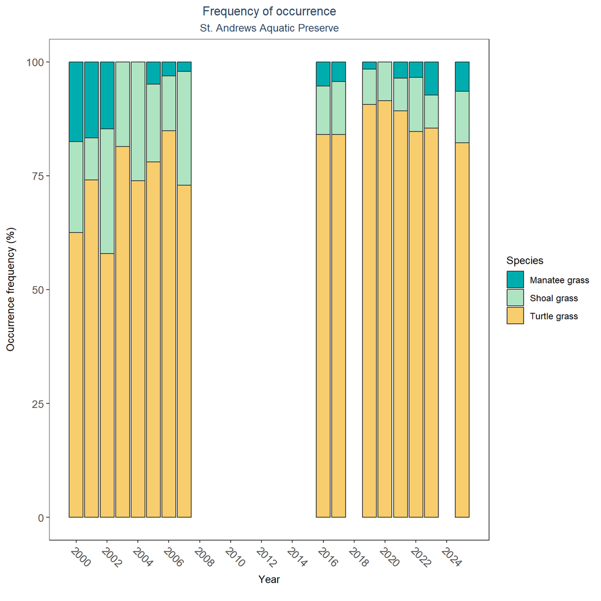

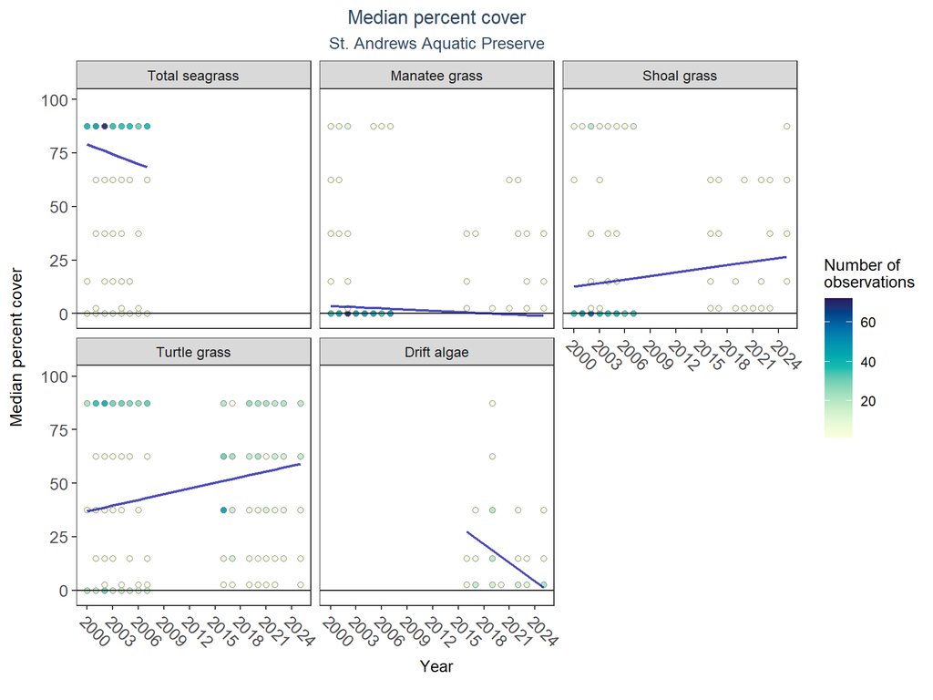

SAV LME Results for St. Andrews Aquatic Preserve

| Species | Statistical Trend | Period of Record | LME Intercept | LME Slope | p |
| --- | --- | --- | --- | --- | --- |
| Drift algae | Decreasing trend | 2016 - 2025 | 91.06 | -2.90 | 0.02 |
| Shoal grass | No detectable trend | 2000 - 2025 | 9.41 | 0.55 | 0.13 |
| Manatee grass | No detectable trend | 2000 - 2025 | 4.67 | -0.19 | 0.77 |
| Turtle grass | No detectable trend | 2000 - 2025 | 31.65 | 0.88 | 0.15 |
| Total seagrass | No detectable trend | 2000 - 2007 | 88.14 | -1.52 | 0.15 |

An annual decrease in percent cover was observed for drift algae (-2.90%). Total seagrass, manatee grass, shoal grass, and turtle grass showed no detectable change in percent cover.

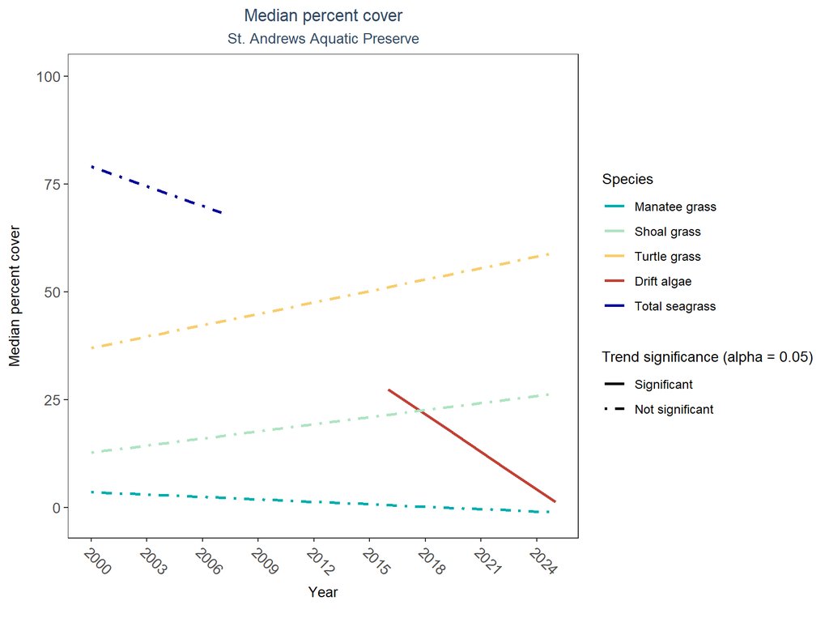

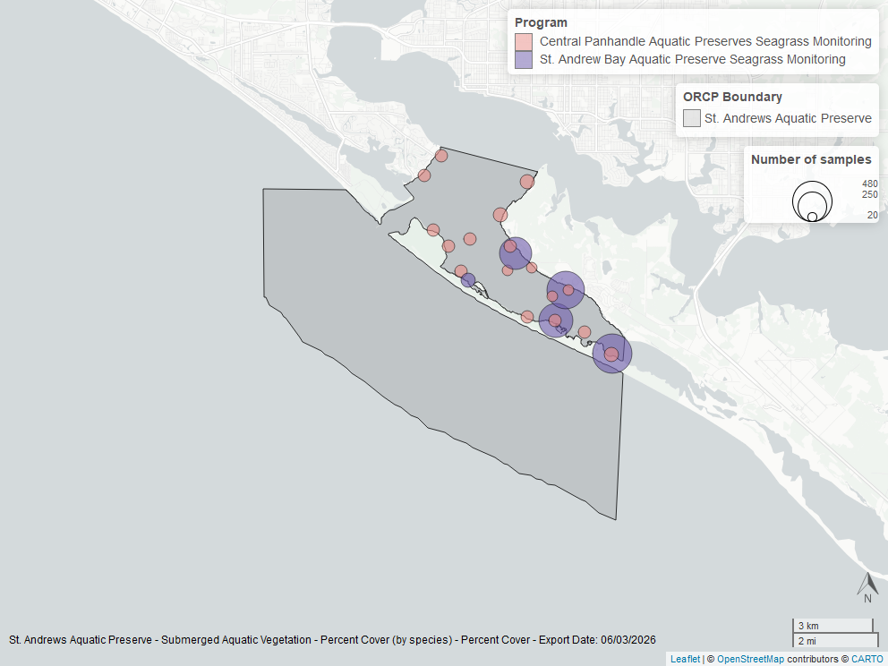

Map showing SAV sampling sites within the boundaries of *St. Andrews Aquatic Preserve*. The point size reflects the number of samples at a given sampling site.

# St. Joseph Bay Aquatic Preserve

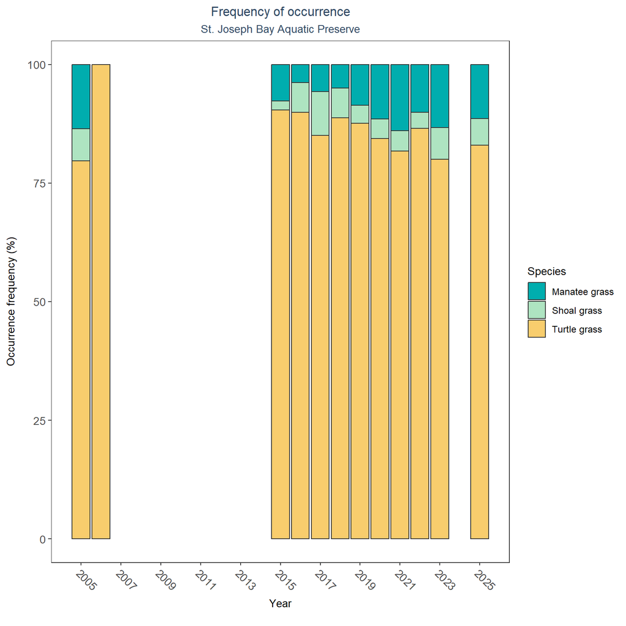

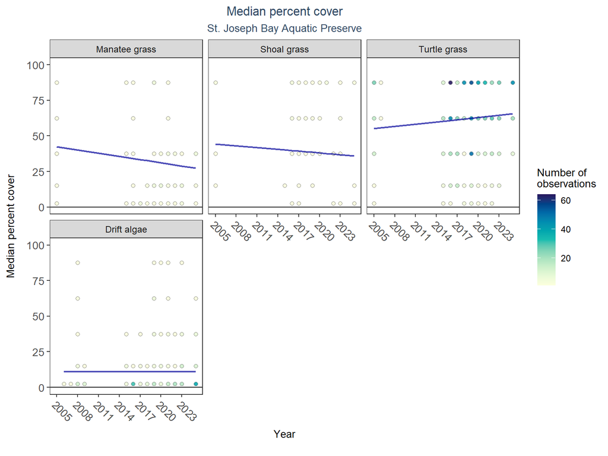

SAV LME Results for St. Joseph Bay Aquatic Preserve

| Species | Statistical Trend | Period of Record | LME Intercept | LME Slope | p |
| --- | --- | --- | --- | --- | --- |
| Drift algae | No detectable trend | 2006 - 2025 | 10.71 | 0.01 | 0.97 |
| Shoal grass | No detectable trend | 2005 - 2025 | 48.88 | -0.41 | 0.58 |
| Manatee grass | No detectable trend | 2005 - 2025 | 50.61 | -0.75 | 0.28 |
| Turtle grass | No detectable trend | 2005 - 2025 | 49.47 | 0.52 | 0.11 |

Manatee grass, shoal grass, turtle grass, and drift algae showed no detectable change in percent cover.

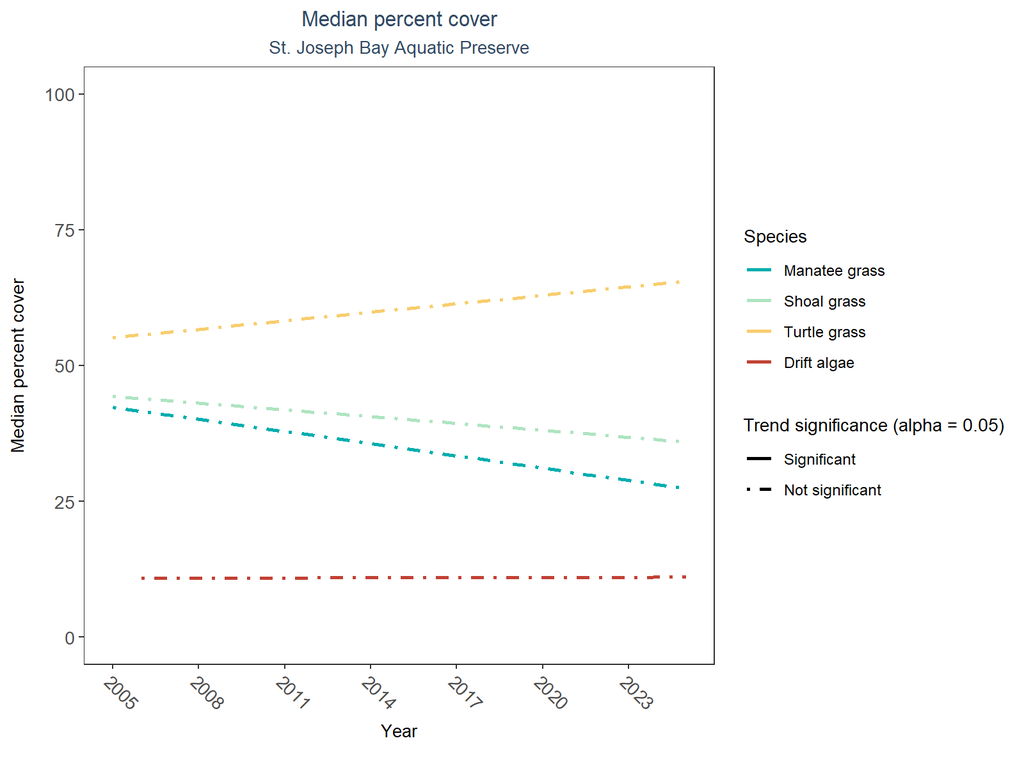

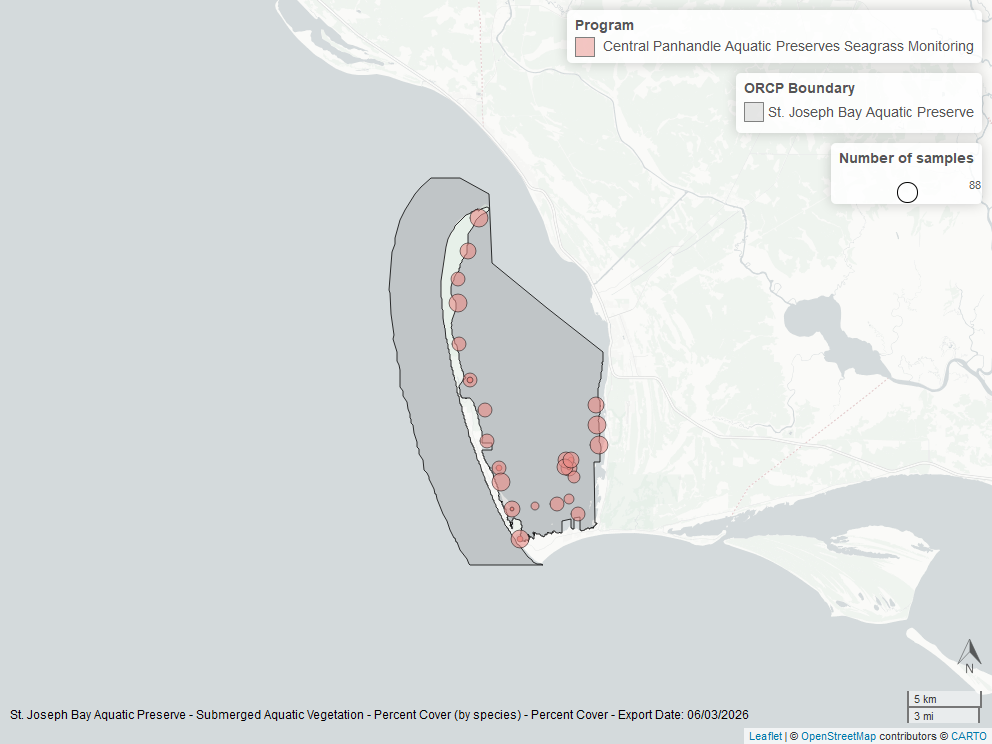

Map showing SAV sampling sites within the boundaries of *St. Joseph Bay Aquatic Preserve*. The point size reflects the number of samples at a given sampling site.

# St. Martins Marsh Aquatic Preserve

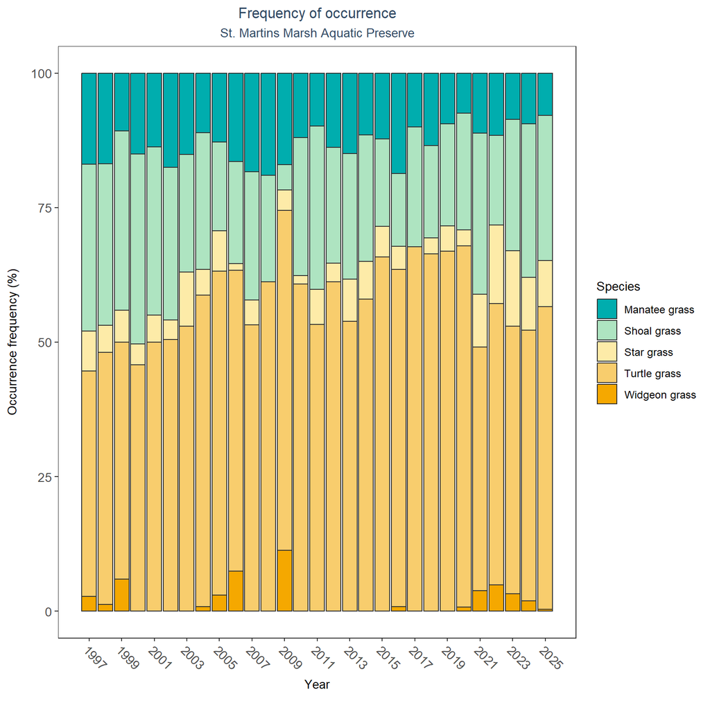

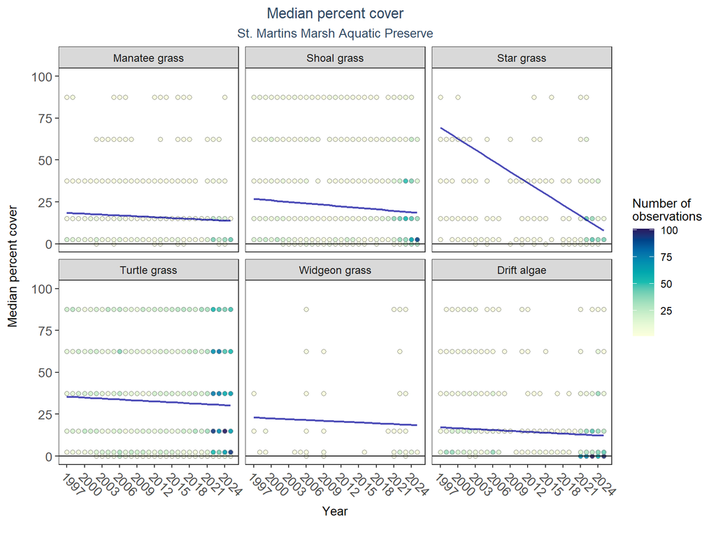

SAV LME Results for St. Martins Marsh Aquatic Preserve

| Species | Statistical Trend | Period of Record | LME Intercept | LME Slope | p |
| --- | --- | --- | --- | --- | --- |
| Drift algae | No detectable trend | 1997 - 2025 | 17.68 | -0.18 | 0.19 |
| Shoal grass | No detectable trend | 1997 - 2025 | 27.73 | -0.29 | 0.10 |
| Star grass | Decreasing trend | 1997 - 2025 | 75.97 | -2.20 | 0.04 |
| Widgeon grass | No detectable trend | 1997 - 2025 | 23.54 | -0.16 | 0.66 |
| Manatee grass | No detectable trend | 1997 - 2025 | 18.96 | -0.17 | 0.39 |
| Turtle grass | No detectable trend | 1997 - 2025 | 36.10 | -0.19 | 0.20 |

An annual decrease in percent cover was observed for star grass (-2.20%). Manatee grass, shoal grass, turtle grass, widgeon grass, and drift algae showed no detectable change in percent cover.

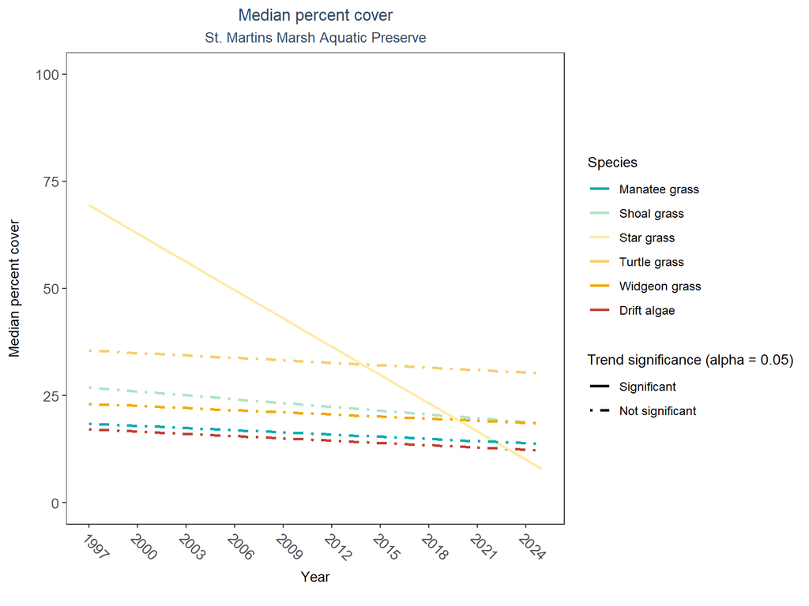

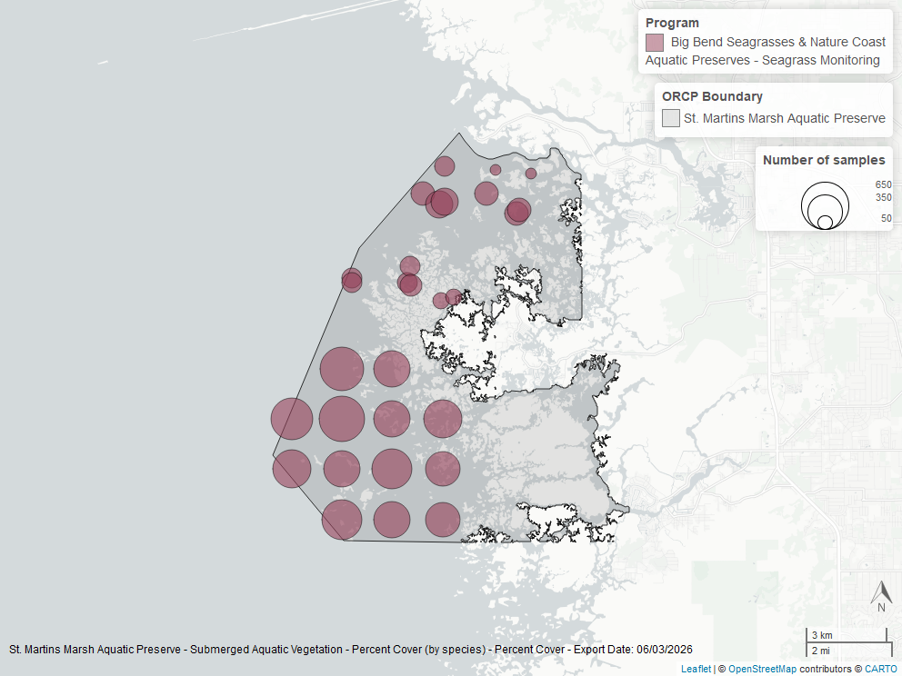

Map showing SAV sampling sites within the boundaries of *St. Martins Marsh Aquatic Preserve*. The point size reflects the number of samples at a given sampling site.

# Terra Ceia Aquatic Preserve

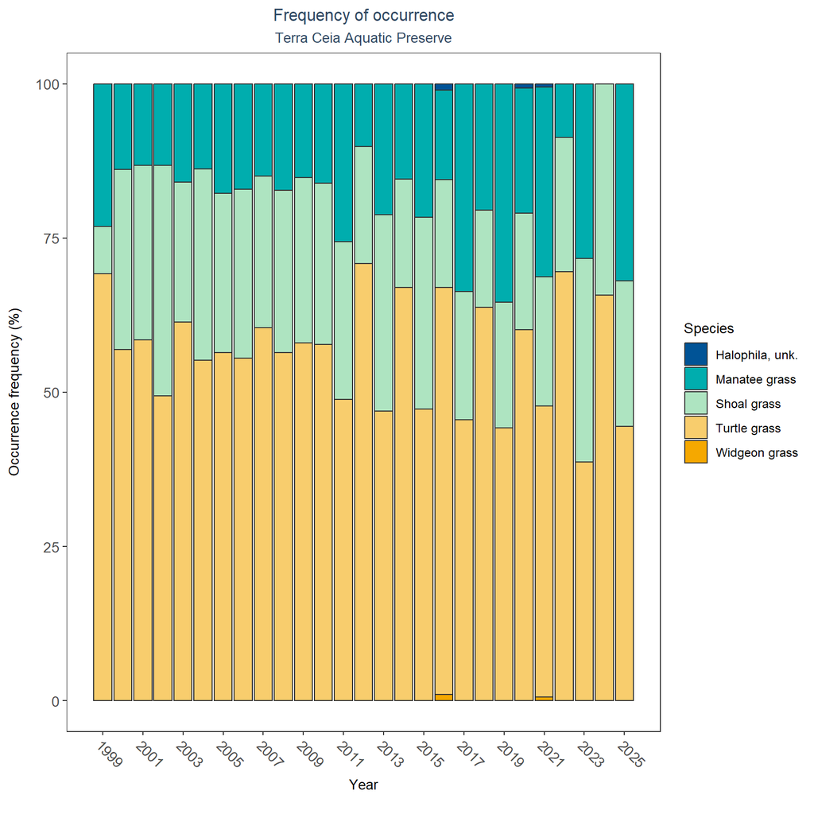

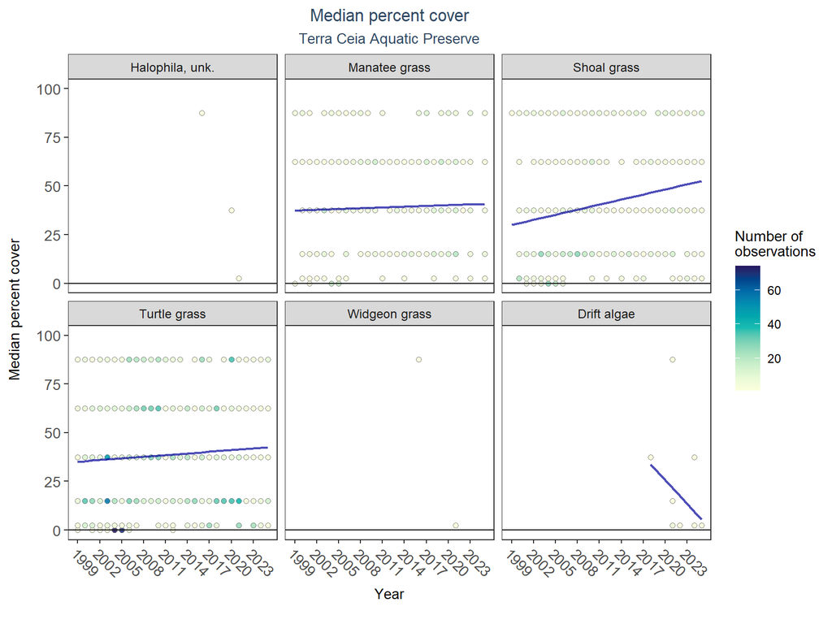

SAV LME Results for Terra Ceia Aquatic Preserve

| Species | Statistical Trend | Period of Record | LME Intercept | LME Slope | p |
| --- | --- | --- | --- | --- | --- |
| Drift algae | No detectable trend | 2018 - 2025 | 131.13 | -4.06 | 0.37 |
| Shoal grass | Increasing trend | 1999 - 2025 | 25.68 | 0.87 | 0.00 |
| Widgeon grass | Insufficient data | 2016 - 2021 | - | - | - |
| Manatee grass | No detectable trend | 1999 - 2025 | 36.73 | 0.13 | 0.72 |
| Turtle grass | No detectable trend | 1999 - 2025 | 33.68 | 0.28 | 0.32 |
| Halophila, unk. | Insufficient data | 2016 - 2021 | - | - | - |

An annual increase in percent cover was observed for shoal grass (0.87%). Manatee grass, turtle grass, and drift algae showed no detectable change in percent cover. Trends in percent cover could not be evaluated for unknown *Halophila* and widgeon grass due to insufficient data.

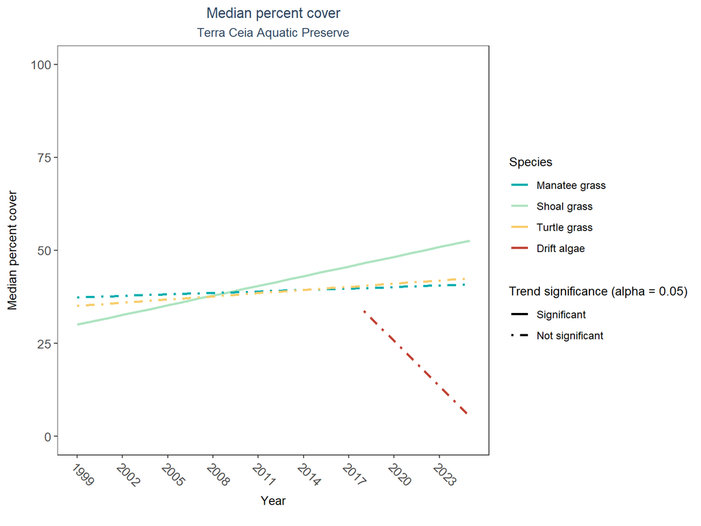

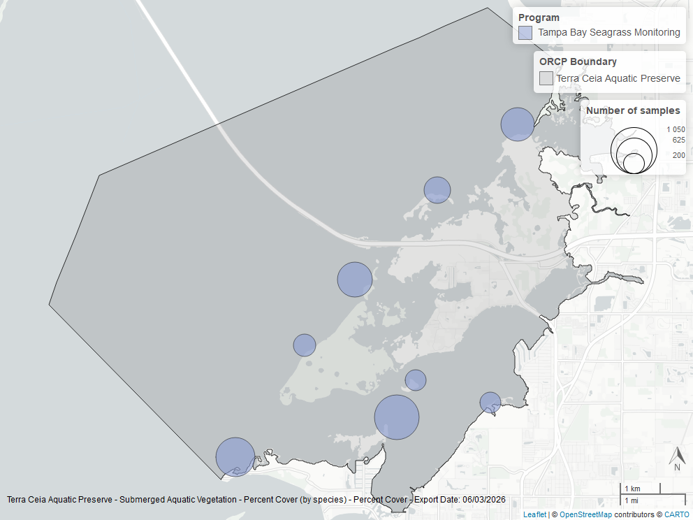

Map showing SAV sampling sites within the boundaries of *Terra Ceia Aquatic Preserve*. The point size reflects the number of samples at a given sampling site.